[(<- Back)](http://mdbrown.github.io/summary.html)

## Mixture Distribution with point mass **NOT** at the high risk threshold.

This serves as an additional simulation to the scenario where the high risk threshold is equal to the risk point mass. This is evidence for the idea that it is the point mass of risk values near the high risk threshold that causes the non-regularity.

### Simulation model

Data is simulated from a linear logistic model with single marker $Y$. We expect there to be problems for $HR_D(r_H)$ when $P(Risk(X_D) = r_H) \neq 0$ (and similarly for $HR_\bar D (r_H)$). This motivates the idea to generate $Y$ from a mixture distribution, where

$Y \sim N(0 , 1)$ with probability (1- $\lambda$ ) and

$Y = y_{risk^*}$ with probability $\lambda$

where the value $y_{risk^*}$ is the value of $Y$ such that $Risk(Y) = risk^*$. We vary $\lambda$ from 0 to 0.25.

5,000 simulationed data sets of sample size 250 were run for each scenario.

### True Measure Values

| rho | HR_D | HR_nD | NB | sNB | AUC | MRD | AARD | lambda |
| --- | --- | --- | --- | --- | --- | --- | --- | --- |
| 0.12 | 0.31 | 0.11 | 0.01 | 0.1 | 0.7 | 0.06 | 0.28 | 0 |
| 0.12 | 0.3 | 0.11 | 0.01 | 0.1 | 0.7 | 0.06 | 0.28 | 0.05 |
| 0.12 | 0.27 | 0.1 | 0.01 | 0.09 | 0.68 | 0.05 | 0.26 | 0.1 |
| 0.12 | 0.23 | 0.08 | 0.01 | 0.08 | 0.66 | 0.04 | 0.22 | 0.25 |

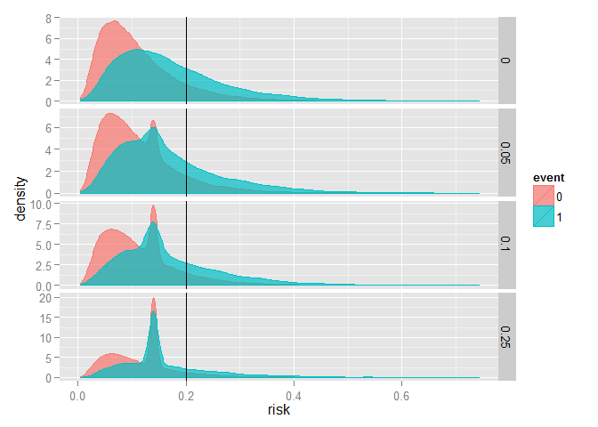

Figure 1: distribution of risk given event status. Risk threshold *rh* shown as a vertical line. lambda is shown on the right

## Evaluate a single risk Model

#### 1.$HR_D(r_H) = P(risk(X) > r_H | D = 1)$

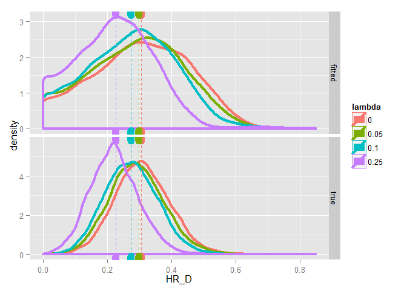

#### 2. $HR_{\bar D}(r_H) = P(risk(X) > r_H | D = 0)$

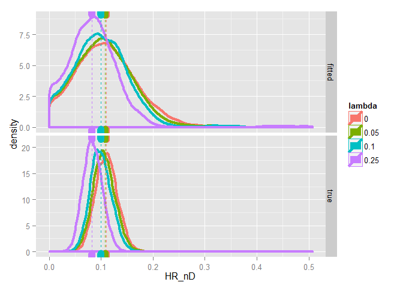

Figure 3: plot of sampling distribution of HR_Dbar(rh) for different values of lambda. calculated using 5000 simulations. true values shown by the vertical lines.

#### 3. $NB(r_H) = \rho HR_D(r_H) - (1-\rho)\frac{r_h}{(1-r_H)}HR_{\bar D}(r_H)$

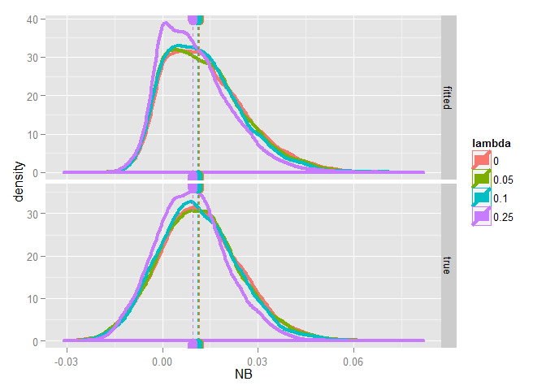

Figure 4: plot of sampling distribution of NB(rh) for different values of lambda. true values shown by the vertical lines.

#### 4. $sNB(r_H) = HR_D(r_H) - \frac{(1-\rho)}{\rho} \frac{r_h}{(1-r_H)}HR_{\bar D}(r_H)$

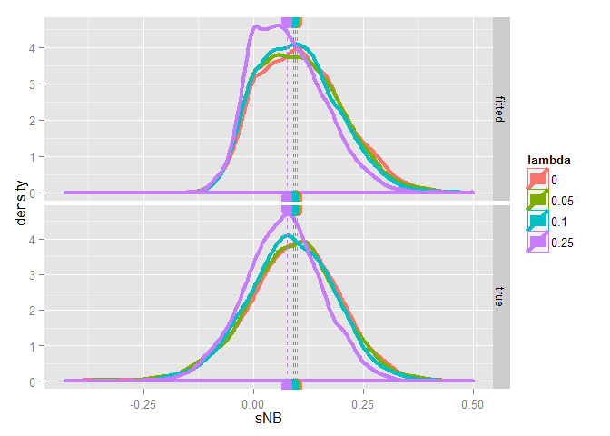

Figure 5: plot of sampling distribution of sNB(rh) for different values of lambda. true values shown by the vertical lines.

### Measures that are independ of $r_H$

Here I include sampling distributions for measures based on fitted risk (conditional estimates) and for measures estimating using risks determined by the true model.

#### 5. $AUC = Pr(risk(X_i ) \geq risk(X_j ) | D_i = 1, D_j = 0 )$

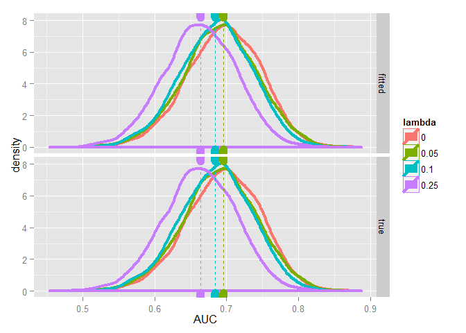

Figure 6: plot of sampling distribution of the AUC for different values of lambda. true values shown by the vertical lines.

#### 6. $MRD = E( risk(X) | D = 1) - E( risk(X) | D =0)$

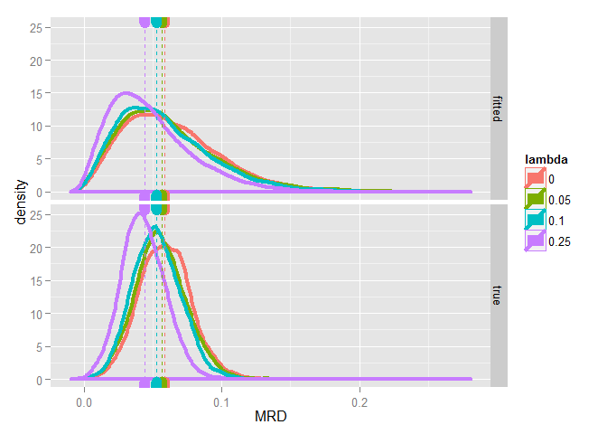

Figure 7: plot of sampling distribution of the MRD for different values of lambda. true values shown by the vertical lines.

#### 7. $AARD = Pr(risk(X) > \rho | D = 1) - Pr(risk(X) > \rho | D = 0)$

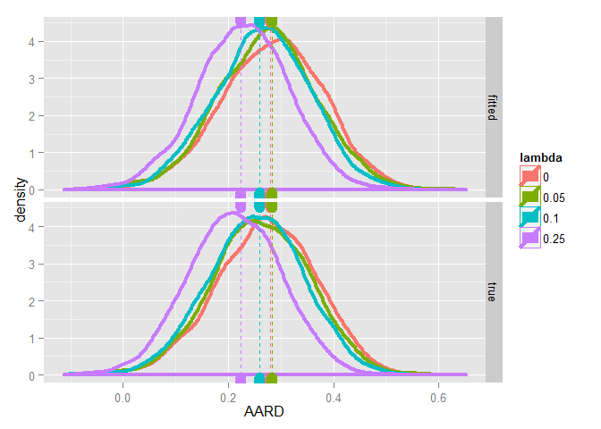